# Visualizing Influence and Community Formation in Online Interaction Networks

## Network Analysis

### Centrality Measures

```r
fb_deg <- degree(fb)
enron_deg <- degree(enron, mode = "all")
summary(fb_deg)
```

```
##    Min. 1st Qu.  Median    Mean 3rd Qu.    Max.
##    1.00    7.00   31.00   75.02   91.50 1841.00
```

```r
summary(enron_deg)
```

```
##     Min.  1st Qu.   Median     Mean  3rd Qu.     Max.
##    1.000    1.000    1.000    7.976    2.000 1778.000
```

### Community Detection

Running the Louvain algorithm reveals the number of distinct communities within each network. For fb-forum, the communities likely reflect conversational clusters, showing different groups of users who tend to interact more often with each other. For Enron, the detected communities may correspond to departments or project groups.

```r
fb_comm <- cluster_louvain(fb)
enron_comm <- cluster_louvain(as.undirected(enron))
length(fb_comm)
```

```
## [1] 14
```

```r
length(enron_comm)
```

```
## [1] 953
```

### Visualize Communities

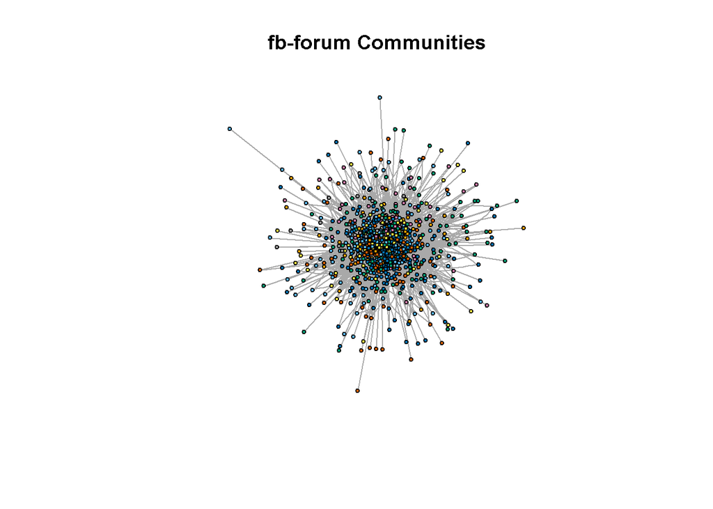

```r
plot(fb, vertex.color=membership(fb_comm), vertex.size=3, vertex.label=NA, main="fb-forum Communities")
```

## Conclusion

From this project, I learned how to use R and igraph to visualize and analyze both synthetic and real-world networks. The fb-forum data revealed informal but structured communities in an open discussion setting, while the Enron dataset helped me understand communication flow and hierarchy within an organization.